# Red Wine Quality by Abhishek Patria

# Description

> In the given project, I will explore the data set on red wines’ quality. The primary motive is to explore the influence of chemical properties on the quality of red wines. This data set contains 1,599 red wines with 11 variables. The data set is available [here](https://s3.amazonaws.com/udacity-hosted-downloads/ud651/wineQualityReds.csv) and information about the data set is available [here](https://s3.amazonaws.com/udacity-hosted-downloads/ud651/wineQualityInfo.txt).

# Dataset Quick-Summary

#### Dataset dimentions:

```
## [1] 1599   13
```

#### Dataset structure:

```
## 'data.frame':    1599 obs. of  13 variables:
##  $ X                   : int  1 2 3 4 5 6 7 8 9 10 ...
##  $ fixed.acidity       : num  7.4 7.8 7.8 11.2 7.4 7.4 7.9 7.3 7.8 7.5 ...
##  $ volatile.acidity    : num  0.7 0.88 0.76 0.28 0.7 0.66 0.6 0.65 0.58 0.5 ...
##  $ citric.acid         : num  0 0 0.04 0.56 0 0 0.06 0 0.02 0.36 ...
##  $ residual.sugar      : num  1.9 2.6 2.3 1.9 1.9 1.8 1.6 1.2 2 6.1 ...
##  $ chlorides           : num  0.076 0.098 0.092 0.075 0.076 0.075 0.069 0.065 0.073 0.071 ...
##  $ free.sulfur.dioxide : num  11 25 15 17 11 13 15 15 9 17 ...
##  $ total.sulfur.dioxide: num  34 67 54 60 34 40 59 21 18 102 ...
##  $ density             : num  0.998 0.997 0.997 0.998 0.998 ...
##  $ pH                  : num  3.51 3.2 3.26 3.16 3.51 3.51 3.3 3.39 3.36 3.35 ...
##  $ sulphates           : num  0.56 0.68 0.65 0.58 0.56 0.56 0.46 0.47 0.57 0.8 ...
##  $ alcohol             : num  9.4 9.8 9.8 9.8 9.4 9.4 9.4 10 9.5 10.5 ...
##  $ quality             : int  5 5 5 6 5 5 5 7 7 5 ...
```

#### Dataset summary:

```
##        X          fixed.acidity   volatile.acidity  citric.acid
##  Min.   :   1.0   Min.   : 4.60   Min.   :0.1200   Min.   :0.000
##  1st Qu.: 400.5   1st Qu.: 7.10   1st Qu.:0.3900   1st Qu.:0.090
##  Median : 800.0   Median : 7.90   Median :0.5200   Median :0.260
##  Mean   : 800.0   Mean   : 8.32   Mean   :0.5278   Mean   :0.271
##  3rd Qu.:1199.5   3rd Qu.: 9.20   3rd Qu.:0.6400   3rd Qu.:0.420
##  Max.   :1599.0   Max.   :15.90   Max.   :1.5800   Max.   :1.000
##  residual.sugar     chlorides       free.sulfur.dioxide
##  Min.   : 0.900   Min.   :0.01200   Min.   : 1.00
##  1st Qu.: 1.900   1st Qu.:0.07000   1st Qu.: 7.00
##  Median : 2.200   Median :0.07900   Median :14.00
##  Mean   : 2.539   Mean   :0.08747   Mean   :15.87
##  3rd Qu.: 2.600   3rd Qu.:0.09000   3rd Qu.:21.00
##  Max.   :15.500   Max.   :0.61100   Max.   :72.00
##  total.sulfur.dioxide    density             pH          sulphates
##  Min.   :  6.00       Min.   :0.9901   Min.   :2.740   Min.   :0.3300
##  1st Qu.: 22.00       1st Qu.:0.9956   1st Qu.:3.210   1st Qu.:0.5500
##  Median : 38.00       Median :0.9968   Median :3.310   Median :0.6200
##  Mean   : 46.47       Mean   :0.9967   Mean   :3.311   Mean   :0.6581
##  3rd Qu.: 62.00       3rd Qu.:0.9978   3rd Qu.:3.400   3rd Qu.:0.7300
##  Max.   :289.00       Max.   :1.0037   Max.   :4.010   Max.   :2.0000
##     alcohol         quality
##  Min.   : 8.40   Min.   :3.000
##  1st Qu.: 9.50   1st Qu.:5.000
##  Median :10.20   Median :6.000
##  Mean   :10.42   Mean   :5.636
##  3rd Qu.:11.10   3rd Qu.:6.000
##  Max.   :14.90   Max.   :8.000
```

> If we see the quality variable, it is an integer variable with a range of [3,8] having a median quality of 6 with the average of 5.636 which might imply a slightly left skewed distribution.

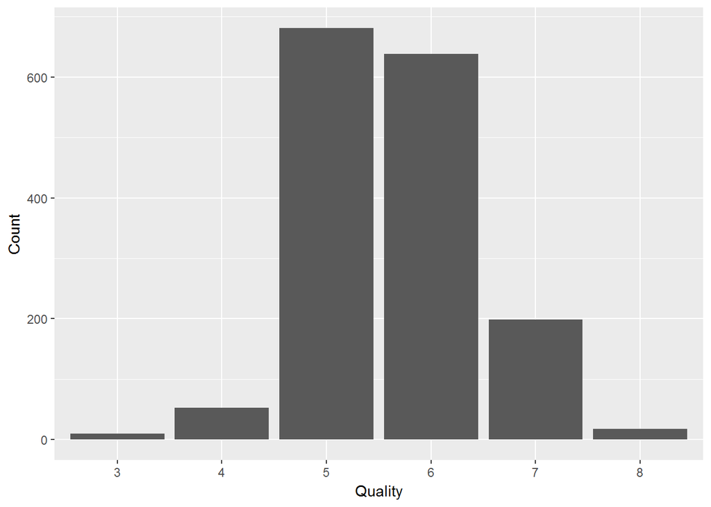

> We can see from the barplot that the distribution is almost symmetrical about its mean value of 5.636 and a slight left skewness.

# Pairwise Matrix

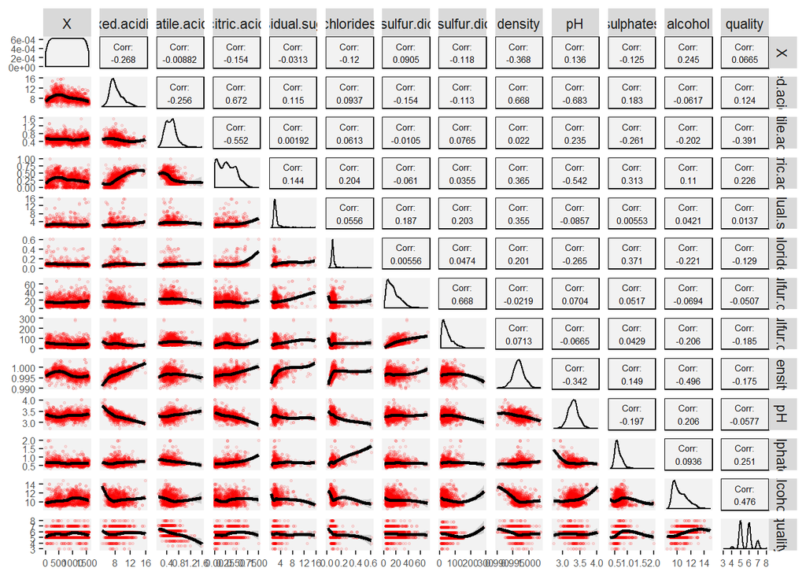

# Univariate Plots

#### Alcohol Content

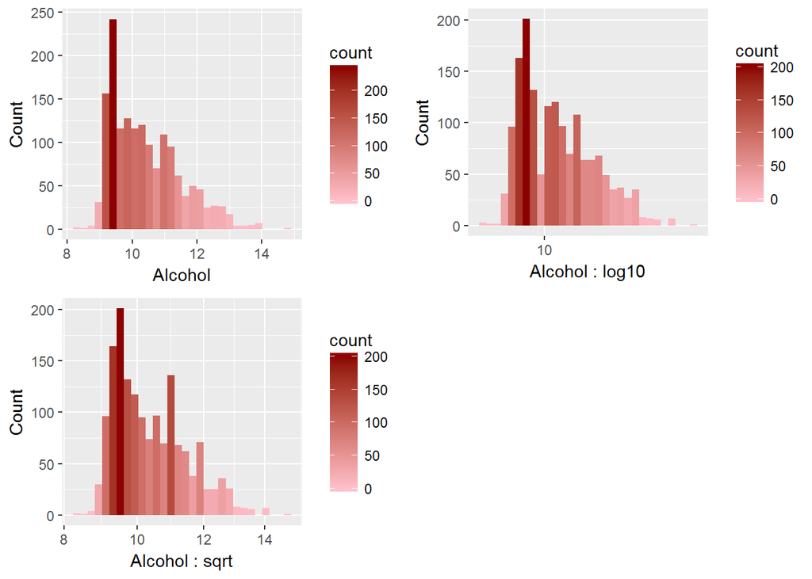

> Being a tailed distribution, plotting the alcohol content with a log and sqrt scale does not help us understanding it.

#### Residual Sugar

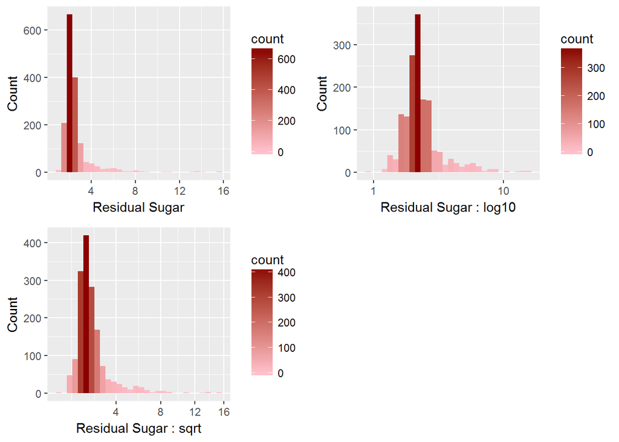

> Residual Sugar is the content that provides with sweet after taste after you take a wine sip. Also, it is an indicator of the quality of fermentation process. Low residual sugar may mean better fermentation process and thus higher alcohol content. It would be interesting to take a look at this in bivariate analysis.

#### Free sulphur, Total sulfur, Bound sulfur

> I have created a new variable “Bound sulfurdioxide” which is Total sulfurdioxide less the free sulfur dioxide, as the free sulfurdioxide has a lot of dispersed distribution.

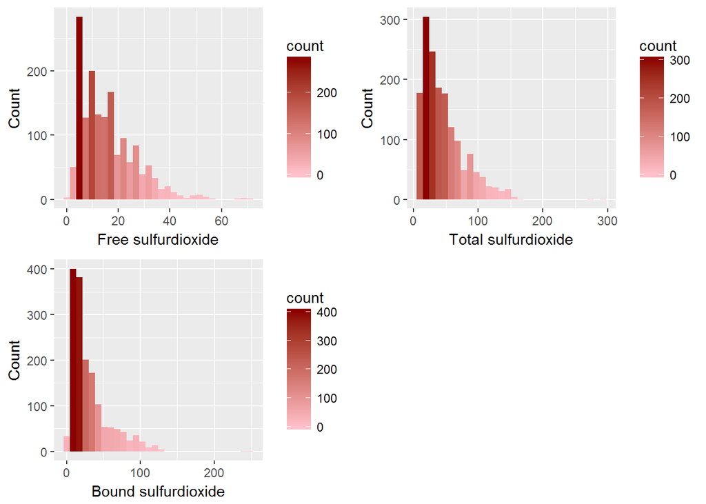

> When plotting on log scale the curve starts acting normally distributed

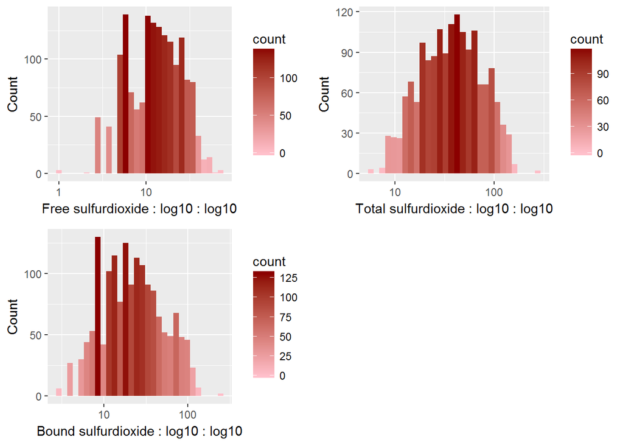

#### Sulphates

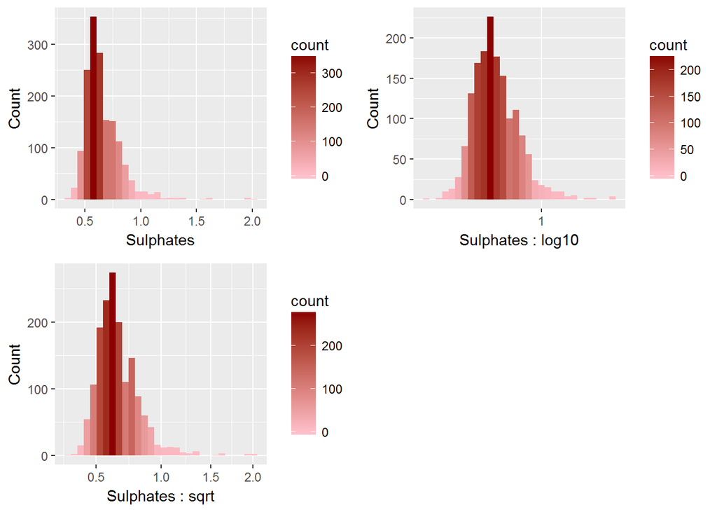

> We see that after applying log scale the distribution tends to be normal but a lot of outliers still remain.

#### Citric acid

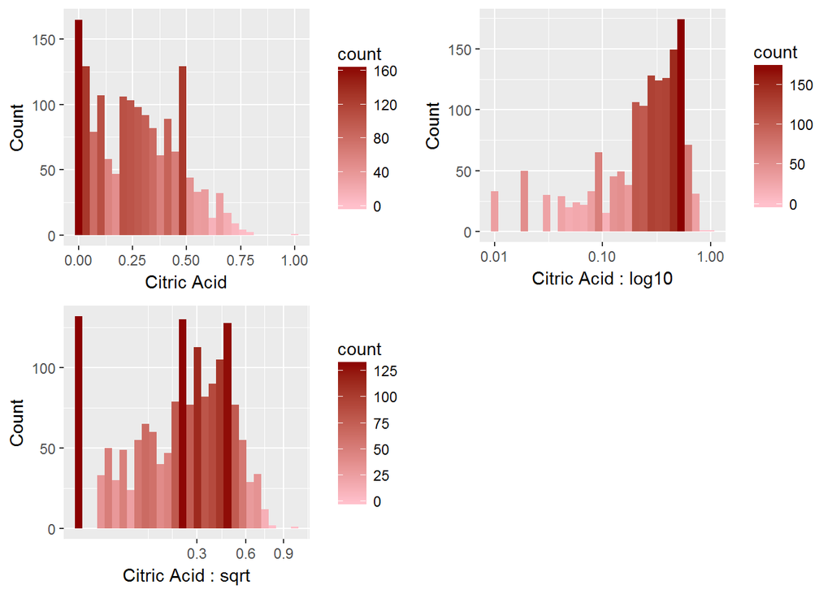

> We see that plotting citric acid on log scale flips the curve on normal scale, while plotting it on sqrt scale starts giving it normal featrue but with a couple of extreme outliers.

#### Fixed acidity, Volatile acidity, Total acidity

[figure not shown]

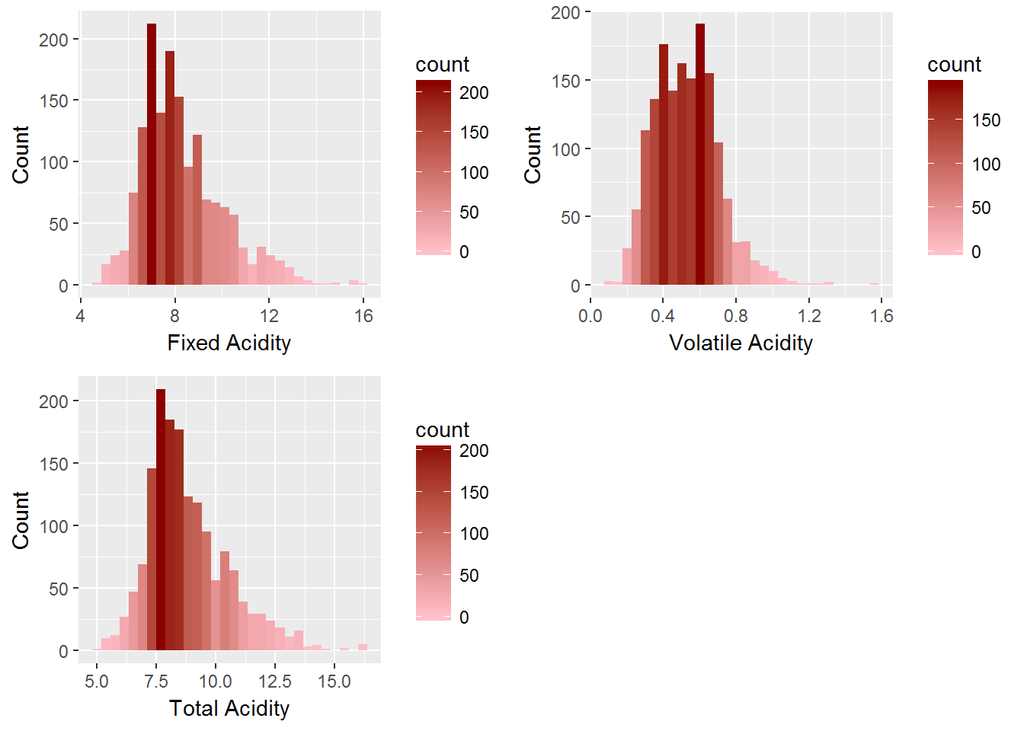

#### Density

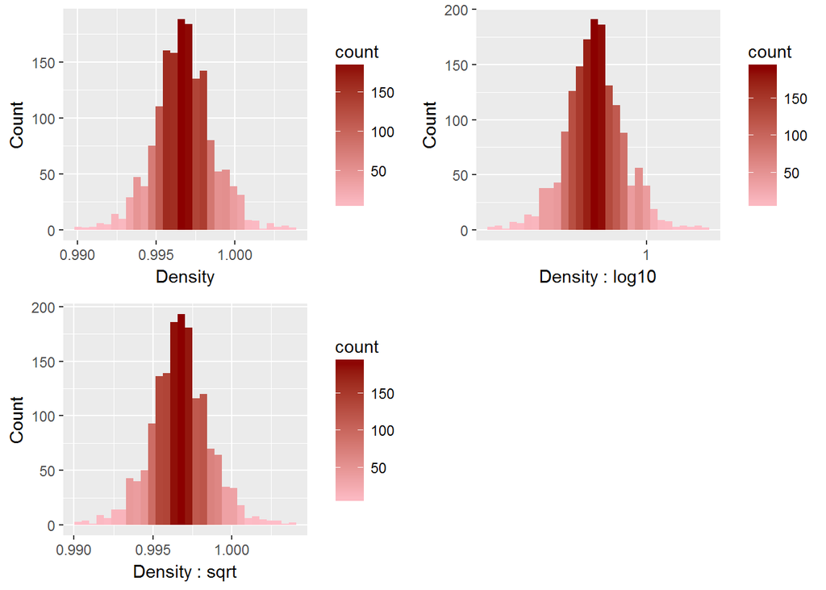

# Univariate Analysis

### Dataset structure:

- We can see that the dataset has 13 variables with 1599 observations
- All the data is of numbers type with integer and numeric being the subtypes
- The variable “x” acts as a unique ID for each row of the data

### Points of interest:

1. pH and density are almost normally distributed
2. Most wines have an alcohol content of less than 11%
3. Residual sugar, chlorides have extreme outliers
4. Sulfur dioxide seems to have normal distribution on a log scale

### Main feature of interest:

It is to see how the quality is being affected by changes in other variables

### Other features in the dataset that will help support my investigation:

I think that Residual sugar, alcohol, sufur, acidity and pH will be the main features that will affect the wine taste. Density may also contribute to the smoothness of the wine.

### New variables created

I have created two new variables as follows:-

1. Bound sulfurdioxide = Total sulfurdioxide - Free sulfurdioxide
2. Total acidity = Fixed acidity + Volatile acidity

Though, I was not able to derive insights from their univariate analysis.

### Of the features you investigated, were there any unusual distributions? Did you perform any operations on the data to tidy, adjust, or change the form of the data? If so, why did you do this?

I had a feeling that most of the data would be normally distributed but then analyzing the variables came as a shocker. This provided a sense how data is in real life.

The data had extreme outliers in the case of residual sugar, chlorides, sulphates. This might represent a case of product differentiation among the wines tested.

# Bivariate Plots Section

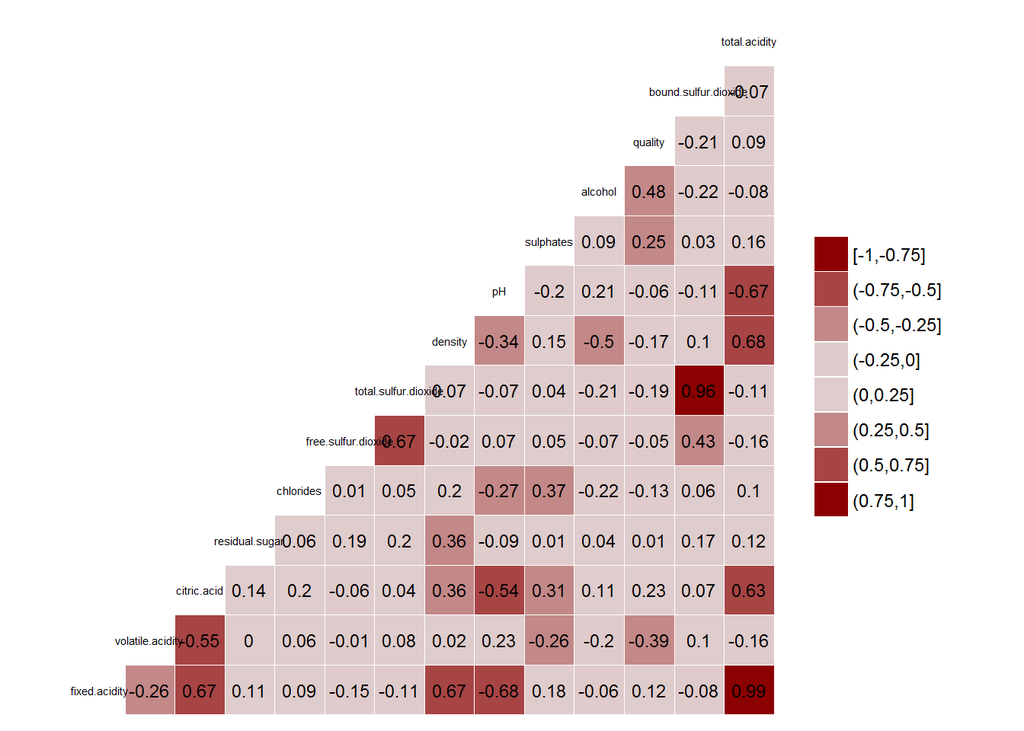

### Let us first plot quality against various variables

> Alcohol vs Quality

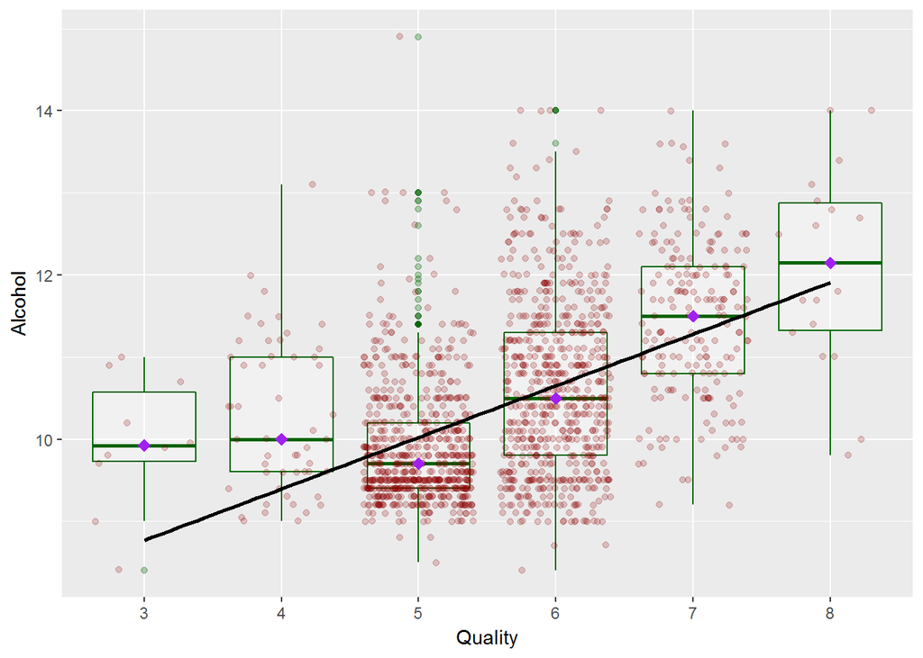

```
##
##  Pearson's product-moment correlation
##
## data:  df$alcohol and df$quality
## t = 21.639, df = 1597, p-value < 2.2e-16
## alternative hypothesis: true correlation is not equal to 0
## 95 percent confidence interval:
##  0.4373540 0.5132081
## sample estimates:
##       cor
## 0.4761663
```

> Volatile Acidity vs Quality

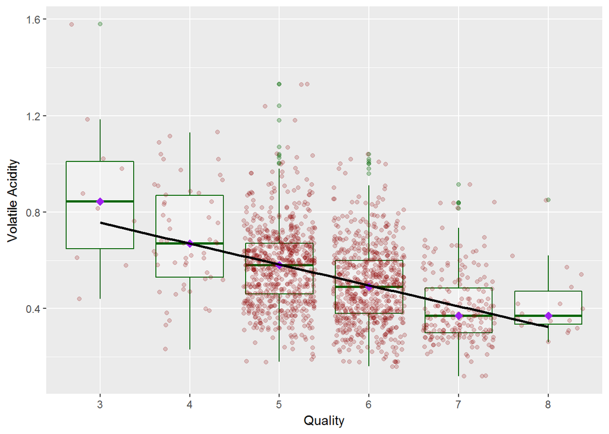

```
##
##  Pearson's product-moment correlation
##
## data:  df$volatile.acidity and df$quality
## t = -16.954, df = 1597, p-value < 2.2e-16
## alternative hypothesis: true correlation is not equal to 0
## 95 percent confidence interval:
##  -0.4313210 -0.3482032
## sample estimates:
##        cor
## -0.3905578
```

> Sulphates vs Quality

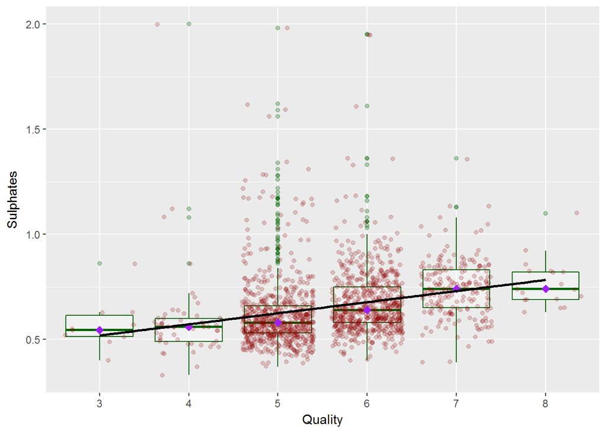

```
##
##  Pearson's product-moment correlation
##
## data:  df$sulphates and df$quality
## t = 10.38, df = 1597, p-value < 2.2e-16
## alternative hypothesis: true correlation is not equal to 0
## 95 percent confidence interval:
##  0.2049011 0.2967610
## sample estimates:
##       cor
## 0.2513971
```

> Citric Acid vs Quality

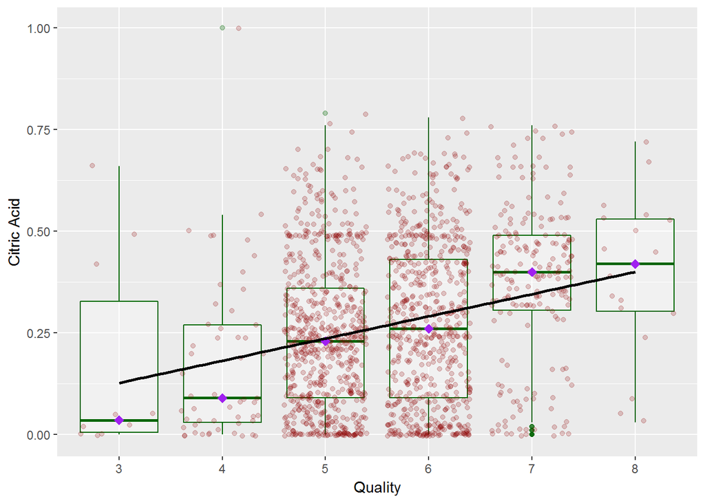

```
##
##  Pearson's product-moment correlation
##
## data:  df$citric.acid and df$quality
## t = 9.2875, df = 1597, p-value < 2.2e-16
## alternative hypothesis: true correlation is not equal to 0
## 95 percent confidence interval:
##  0.1793415 0.2723711
## sample estimates:
##       cor
## 0.2263725
```

> Total Sulfhur Dixoide vs Quality

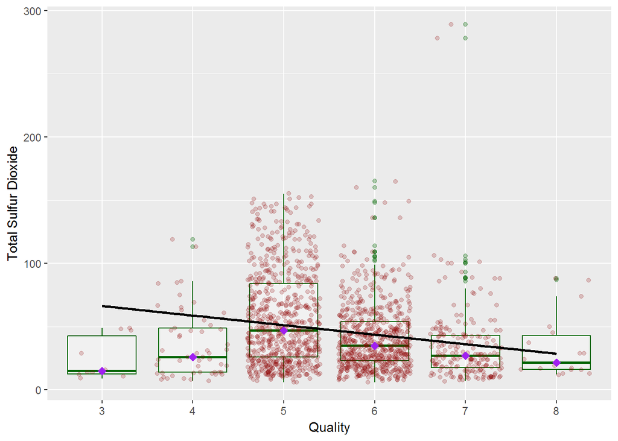

```
##
##  Pearson's product-moment correlation
##
## data:  df$total.sulfur.dioxide and df$quality
## t = -7.5271, df = 1597, p-value = 8.622e-14
## alternative hypothesis: true correlation is not equal to 0
## 95 percent confidence interval:
##  -0.2320162 -0.1373252
## sample estimates:
##        cor
## -0.1851003
```

> pH vs Quality

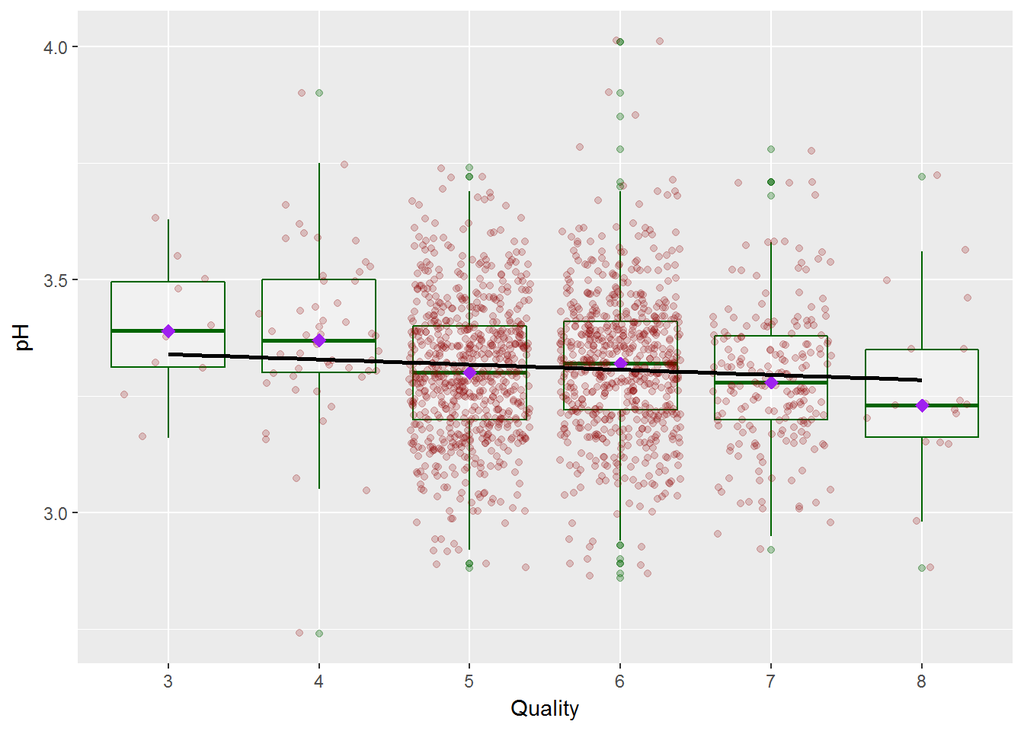

```
##
##  Pearson's product-moment correlation
##
## data:  df$pH and df$quality
## t = -2.3109, df = 1597, p-value = 0.02096
## alternative hypothesis: true correlation is not equal to 0
## 95 percent confidence interval:
##  -0.106451268 -0.008734972
## sample estimates:
##         cor
## -0.05773139
```

> Density vs Quality

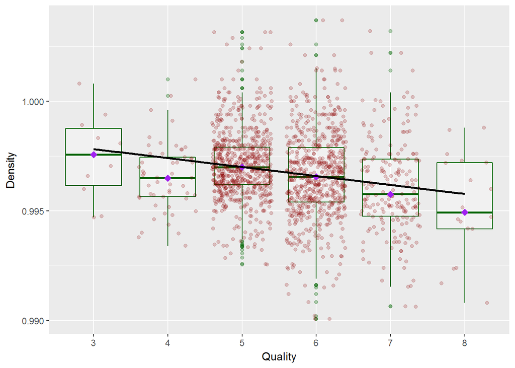

```
##
##  Pearson's product-moment correlation
##
## data:  df$density and df$quality
## t = -7.0997, df = 1597, p-value = 1.875e-12
## alternative hypothesis: true correlation is not equal to 0
## 95 percent confidence interval:
##  -0.2220365 -0.1269870
## sample estimates:
##        cor
## -0.1749192
```

> Free Sulfur Dioxide vs Quality

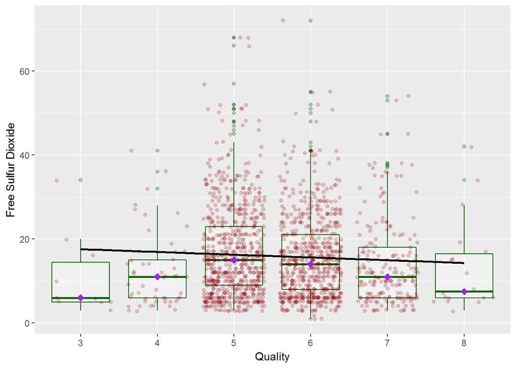

```
##
##  Pearson's product-moment correlation
##
## data:  df$free.sulfur.dioxide and df$quality
## t = -2.0269, df = 1597, p-value = 0.04283
## alternative hypothesis: true correlation is not equal to 0
## 95 percent confidence interval:
##  -0.099430290 -0.001638987
## sample estimates:
##         cor
## -0.05065606
```

> Chlorides vs Quality

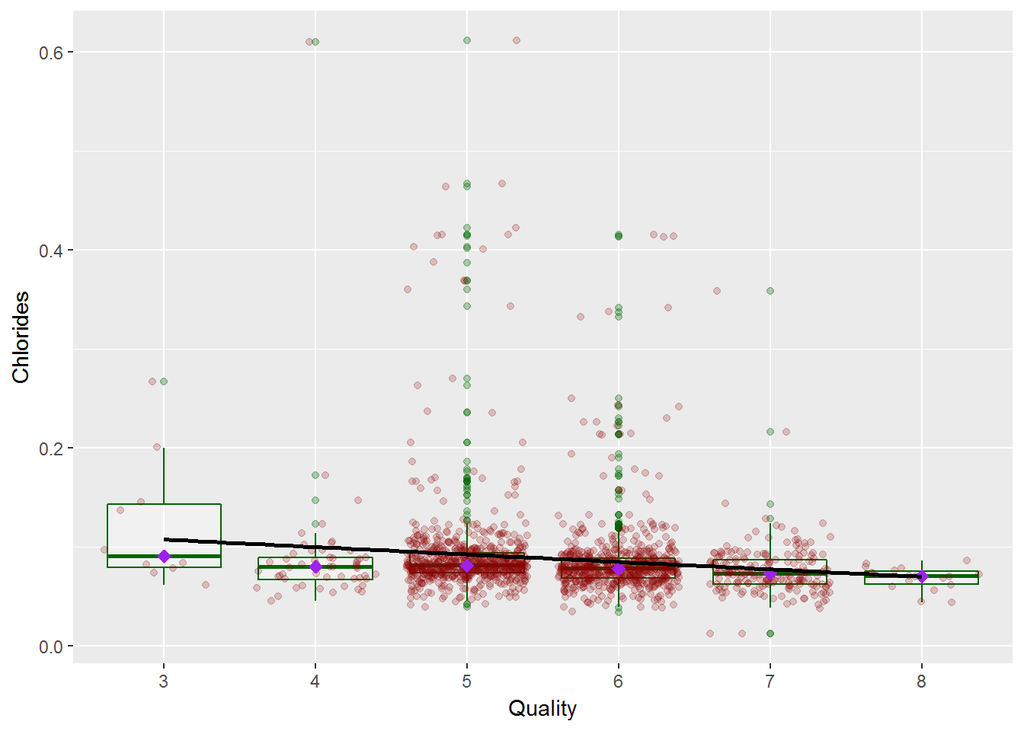

```
##
##  Pearson's product-moment correlation
##
## data:  df$chlorides and df$quality
## t = -5.1948, df = 1597, p-value = 2.313e-07
## alternative hypothesis: true correlation is not equal to 0
## 95 percent confidence interval:
##  -0.17681041 -0.08039344
## sample estimates:
##        cor
## -0.1289066
```

> Residual Sugar vs Quality

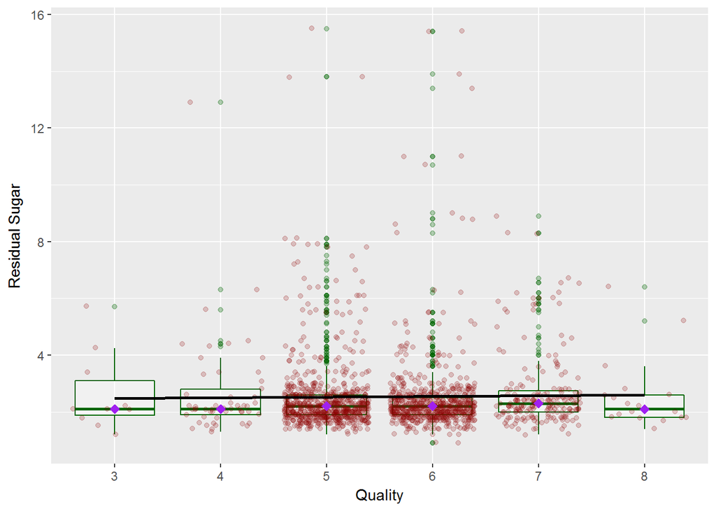

```
##
##  Pearson's product-moment correlation
##
## data:  df$residual.sugar and df$quality
## t = 0.5488, df = 1597, p-value = 0.5832
## alternative hypothesis: true correlation is not equal to 0
## 95 percent confidence interval:
##  -0.03531327  0.06271056
## sample estimates:
##        cor
## 0.01373164
```

> Fixed Acidity vs Quality

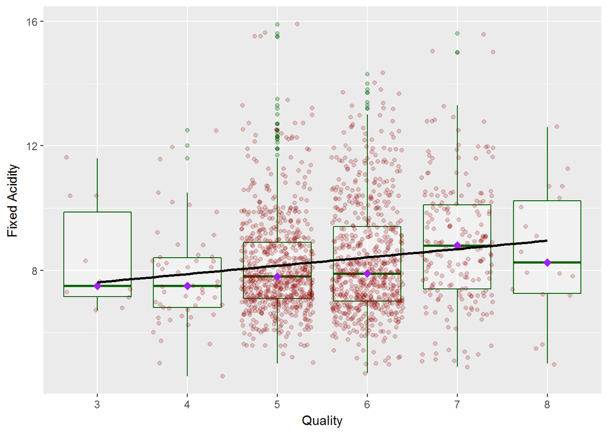

```
##
##  Pearson's product-moment correlation
##
## data:  df$fixed.acidity and df$quality
## t = 4.996, df = 1597, p-value = 6.496e-07
## alternative hypothesis: true correlation is not equal to 0
## 95 percent confidence interval:
##  0.07548957 0.17202667
## sample estimates:
##       cor
## 0.1240516
```

> Fixed Acidity vs Density

[figure not shown]

```
##
##  Pearson's product-moment correlation
##
## data:  df$density and log(df$fixed.acidity)
## t = 36.537, df = 1597, p-value < 2.2e-16
## alternative hypothesis: true correlation is not equal to 0
## 95 percent confidence interval:
##  0.6471556 0.7006162
## sample estimates:
##       cor
## 0.6747701
```

> Fixed Acidity vs pH

[figure not shown]

```
##
##  Pearson's product-moment correlation
##
## data:  df$pH and log(df$fixed.acidity)
## t = -39.878, df = 1597, p-value < 2.2e-16
## alternative hypothesis: true correlation is not equal to 0
## 95 percent confidence interval:
##  -0.7301005 -0.6809169
## sample estimates:
##        cor
## -0.7063602
```

> The smoothened curve can be taken as a near straight line.

# Bivariate Analysis

### Quality against other variables

> I was not able to find a strong correlation between quality and other variables. But if seen as best amongst bad, alcohol, volatile acidity, sulphates and citric acid are the variables that may be used in developing a linear model to predict quality.

# Multivariate Plots Section

> I have plotted fixed acidity against density and pH with quality breakup as these combinations have the strongest correlation in the correlation matrix.

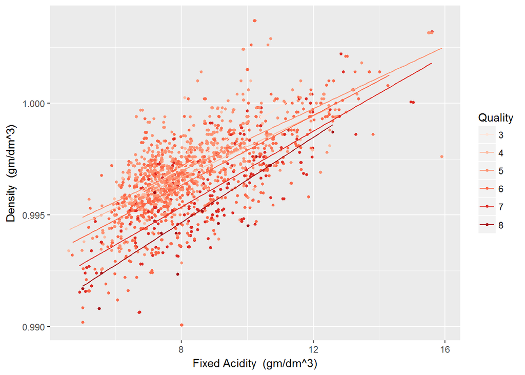

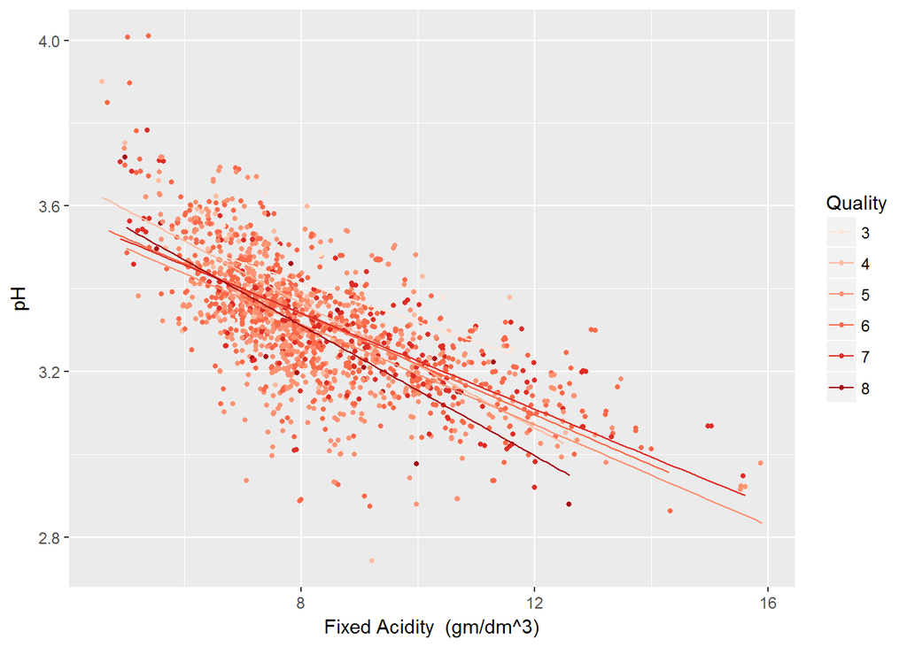

> With alcohol and volatile acidity being strongly correlated with the quality of the red wine, it is a must to explore the dependence of these two with their respective strongest correlations. As a result I have plotted density vs alcohol and citric acid vs volatility.

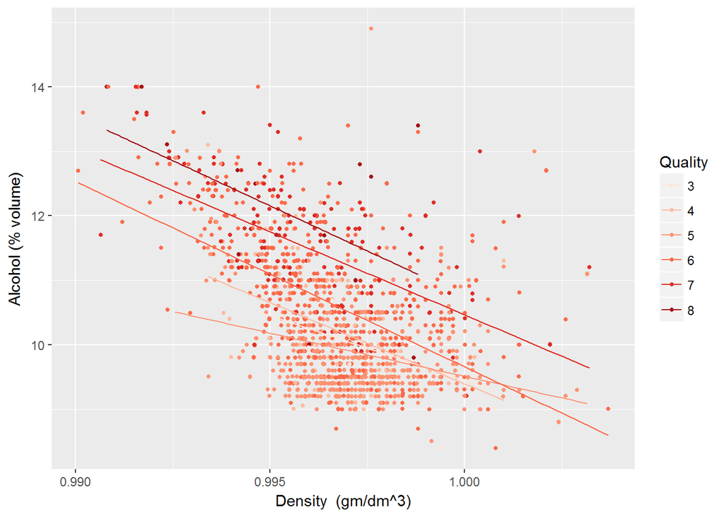

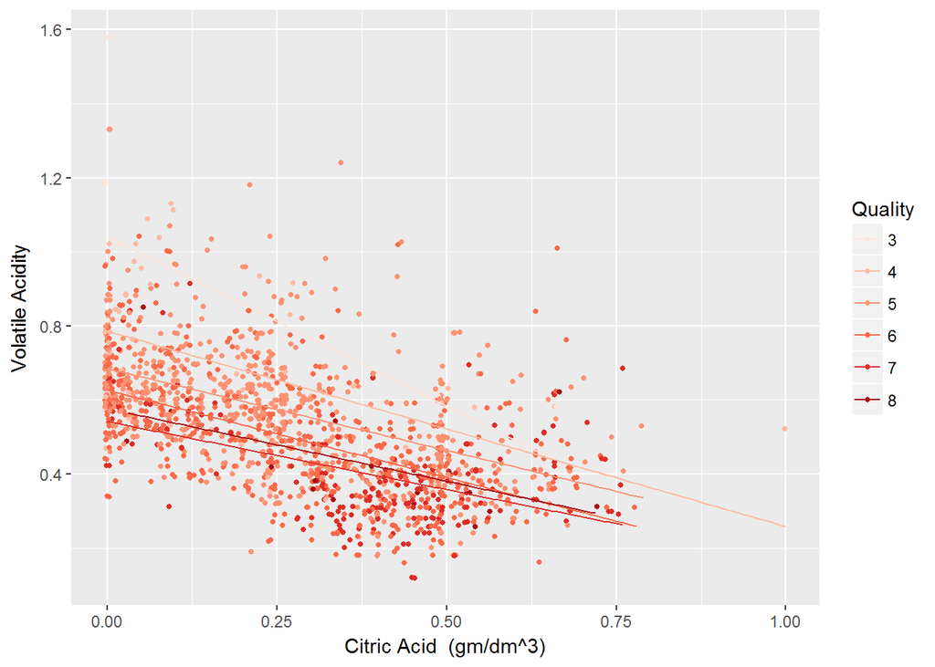

# Multivariate Analysis

### Relationships observed:

Density and fixed acidity go hand in hand and they are apparently converging at higher units.

### Surprising interactions between features:

Though there is a strong correlation between pH and fixed acidity, this does not reveal any individual insight about the quality as around an acidity of 6.5 the trend changes for quality.

# Final Plots and Summary

### Plot One

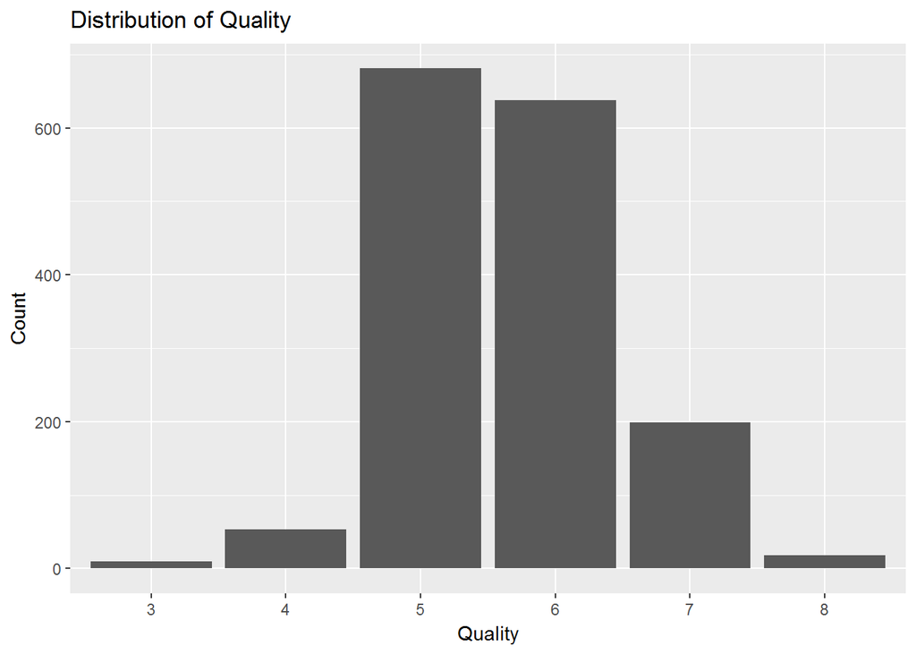

```
##    Min. 1st Qu.  Median    Mean 3rd Qu.    Max.
##   3.000   5.000   6.000   5.636   6.000   8.000
```

### Description One

Wines with quality 5-6 make up most of the space i.e. they are mainstream, while high or low quality wines have a very small ratio: this in combination provides us with the apparently normal distribution of quality of wines.

### Plot Two

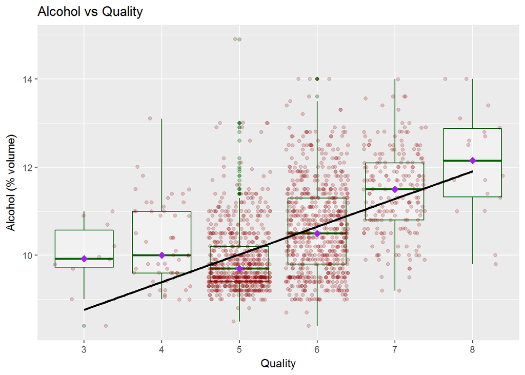

### Description Two

Alcohol has the strongest correlation with the quality when compared to other variables, it is better to see its pattern with varying quality. From the above plot, it can be seen that higher % of alcohol yields better wine.

### Plot Three

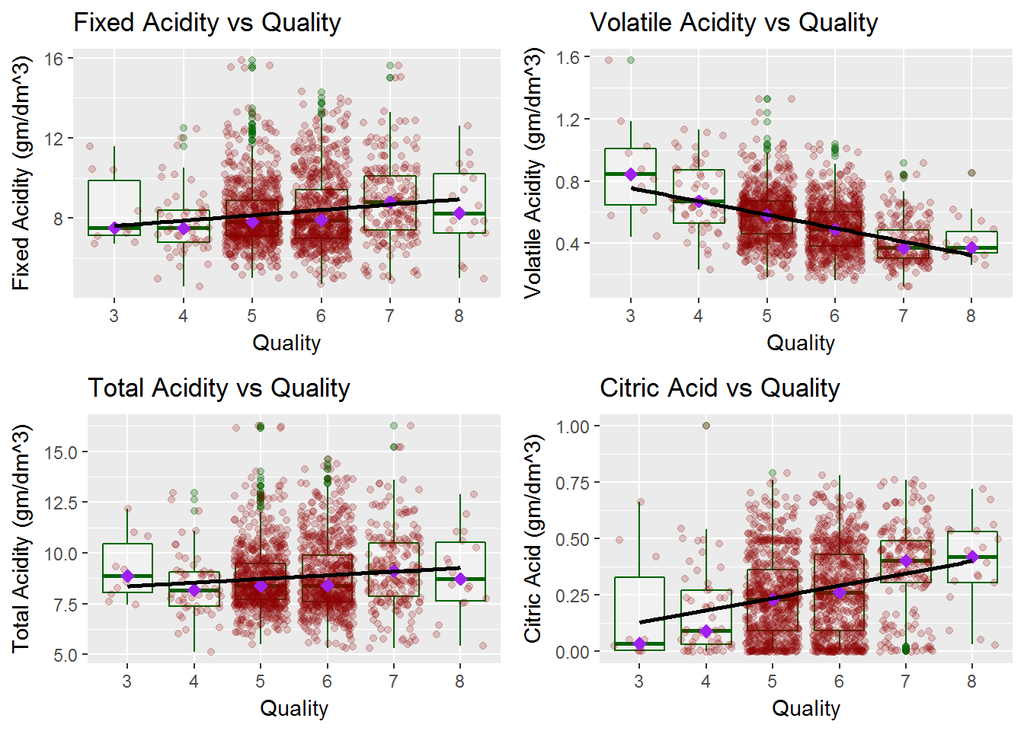

### Description Three

Volatile acid has a strong negative correlation with wine quality fixed acidity, total acidity and citric acid has a positive relationship with wine quality.

# Reflection

While the dataset is small in size, it has a lot of variables to explore. The analysis performed above is purely statistical and does not include the domain knowledge of wine tasting. The dependence of quality can be mainly explained by alcohol, acid and sulphates.

Also, correlation does not equate to causation. Moreover, domain knowledge is of utmost importance to clean, understand, generate new insights and inferences from the data.